# What is the value of the Macedonian parliament? Part 1: Gender analysis

DiscindoDataBrew

## About

This document shows data from the property sheets that Macedonian MPs report to the State anti-corruption commission. The data are for the new MPs whose mandate was ratified in December 2016.

The data are for 100 MPs because that many of them had their property sheets published/updated until 24.02.2017 on the commission’s website.

Errors can be reported [here](https://github.com/novica/databrew/issues). The source code is published [here](https://github.com/novica/databrew/).

## Introductions

The total property of these 100 MPs is 24 Million EUR, calculated as a sum of all types of properties minus the debts. [How much is 24 million EUR](https://www.google.com/#q=24+million+eur)?

### Property by type

Macedonian MPs and their families mostly own real estate. In fact all of the other types of property that they own, are more or less equal to the debts. The 24 million EUR is more or less the value of the real estate.

Table 1: Property by type in EUR

| Property | Total |
| --- | --- |
| Real Estate | 24.618.637 |
| Debt | 4.677.112 |
| Movables | 2.153.051 |
| Bank Deposits | 1.114.695 |
| Shares | 677.997 |
| Financial Claims | 423.120 |
| Other Property | 330.007 |
| Other Income | 94.468 |

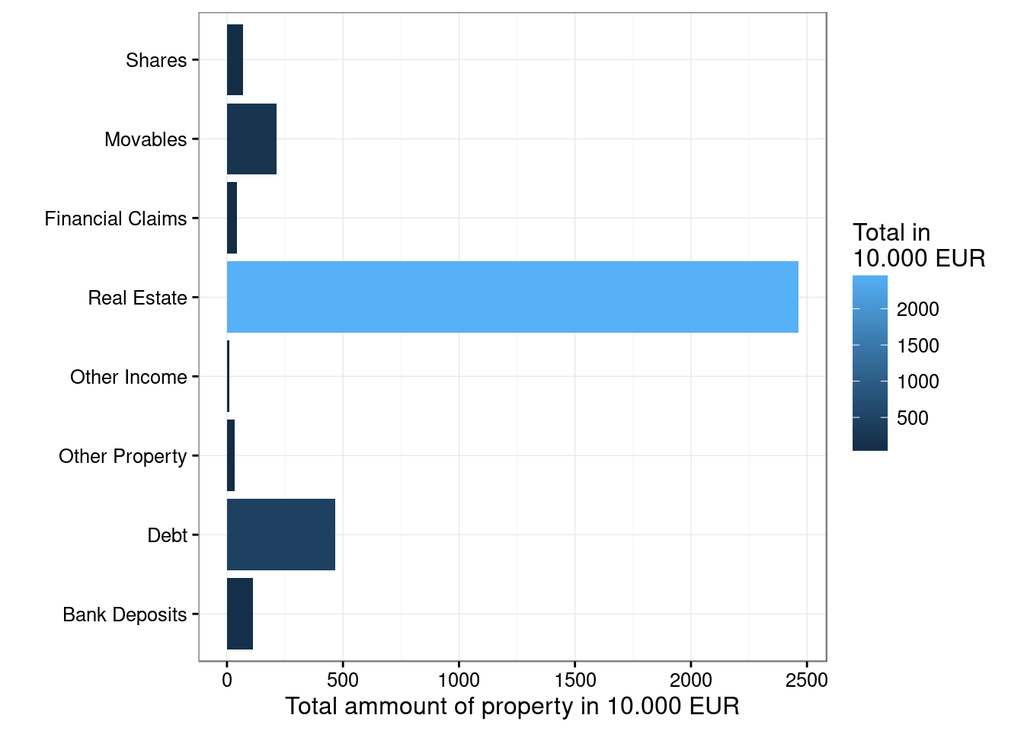

Image 1: Property by type

### Gender distribution of property

The gender distribution of property reveals a gap between men and women in Parliament, and between them and their spouses. The tables below show the property by type that is owned by by male MPs and the spouses of female MPs, and female MPs and the spouses of male MPs.

The most interesting thing is that women: female MPs and spouses of male MPs are the main owners of debt in the Macedonian Parliament.

Table 2: Property of men by type

| Property | Total |
| --- | --- |
| Real Estate | 11.115.829 |
| Movables | 1.452.746 |
| Bank Deposits | 574.827 |
| Debt | 567.833 |
| Shares | 452.392 |
| Financial Claims | 206.448 |
| Other Property | 76.637 |
| Other Income | 59.365 |

Table 3: Property of women by type

| Property | Total |
| --- | --- |
| Debt | 3.752.296 |
| Real Estate | 2.166.799 |
| Bank Deposits | 341.874 |
| Movables | 289.235 |
| Financial Claims | 78.049 |
| Other Property | 47.250 |
| Shares | 27.308 |
| Other Income | 2.917 |

A detailed analysis of property types suggests that female MPs and spouses of male MPs are in a notably worse position when compared to their mail peers. Both the spouses and parents of female MPs own more than the female MPs. Female MPs mostly, and compared to everyone else, have debts.

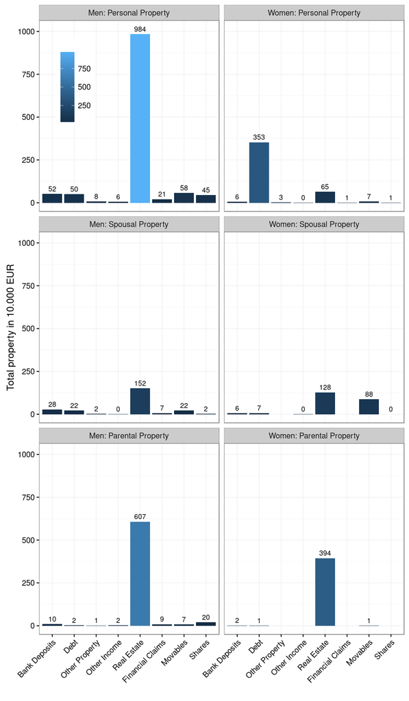

Image 2: Gender distribution of property

Update 28.02.2017: The main “debtor” amnogn the female MPs is just one MP. If the property sheets are cprrect, Nola Ismajloska Starova has a debt of 3.4 million EUR. This debt occured sometime between April 3 2016 when the [previous property sheet](https://data-mkopen.rhcloud.com/diff/+xhLVIsvfe+AQq5agPdMYw) was submitted to the watchdog commission and February 1 2017 when the [new one was submitted](http://www.dksk.org.mk/imoti_2/detail.php?detail=11607&search=&ime=%D0%BD%D0%BE%D0%BB%D0%B0&prezime=&funkcija=&institucija=).